# Analysis for ‘Coloured vs black and white object preferences in Trinidadian guppies’

My File Drawer [GitHub](https://github.com/wyatt-toure/file-drawer-research)

Guppy preferences for colour Guppy novel object recognition Guppy colour learning v1

Guppy preferences for colour Guppy novel object recognition Guppy colour learning v1

Home

M. Wyatt Toure

e-mail: `m_wyatt.toure@mail.mcgill.ca`

## Brief Overview

For this experiment I wanted to figure out how guppies responded to the Lego objects I wanted to use for my main experiments. I knew that there was extensive evidence that guppies preferred carotenoid colours so I wanted to see if I presented guppies of both sexes with a colourful object (containing red, yellow, and orange) as well as a black and white object, would they show a preference for the colourful object.

```r
full_data <- read.csv("data/colour-vs-bw-object-preference-data.csv")
```

## Data preparation

### Checking data

```r
kable(
  describe_all_cat(full_data) %>%
    filter(Variable != "id"),
  caption = ""
)
```

Table 1:

| Variable | Group | Frequency | % |
| --- | --- | --- | --- |
| sex | F | 10 | 50 |
| sex | M | 10 | 50 |
| orientation | N | 10 | 50 |
| orientation | R | 10 | 50 |

### Variable creation

```r
# Creating close colour object preference
full_data <- full_data %>% mutate(
  close.colour.object.preference =
    colour.object.close.time - bw.object.close.time
)

# Creating colour object side preference
full_data <- full_data %>% mutate(
  colour.object.side.preference =
    colour.object.side.time - bw.object.side.time
)
```

## Models

### Model 1

```r
model_1 <- lm(close.colour.object.preference ~ 1,
  data = full_data
)
```

Table 2:

| term | estimate | std.error | statistic | p.value |
| --- | --- | --- | --- | --- |
| (Intercept) | -4.174093 | 7.869286 | -0.5304285 | 0.60196 |

There was no significant preference for one object over the other across all guppies.

### Model 2

I wondered whether there may be sex differences in the data since males and females might react differently to a large coloured object. I therefore fit a linear model with the close coloured object preference metric and a fixed effect of sex.

```r
model_2 <- lm(close.colour.object.preference ~ sex,
  data = full_data
)
```

Table 3:

| term | estimate | std.error | statistic | p.value |
| --- | --- | --- | --- | --- |
| (Intercept) | 6.226077 | 10.89559 | 0.5714312 | 0.5747740 |
| sexM | -20.800341 | 15.40868 | -1.3499102 | 0.1937772 |

There is no significant effect of sex on coloured object preference.

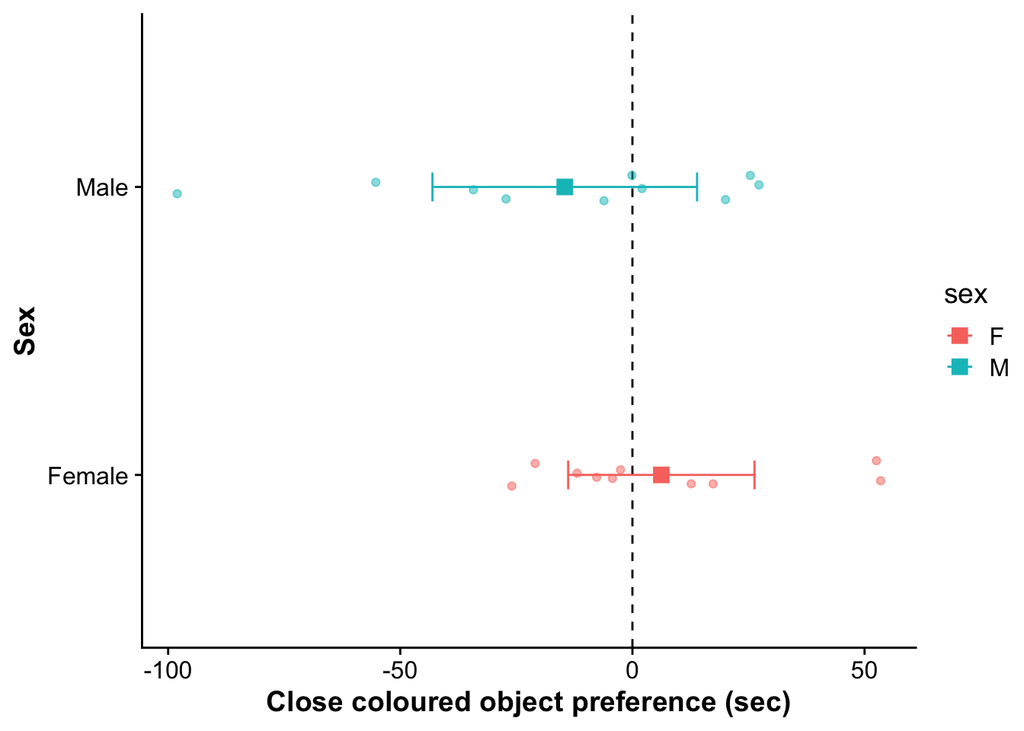

Figure 1: Preference for the coloured object separated by sex. Positive values to the right of the dashed line indicate a preference for the coloured object. Negative values to the left of the dashed line indicate a preference for the black and white object.

### Model 3

```r
model_3 <- lm(colour.object.side.preference ~ sex,
  data = full_data
)
```

Table 4:

| term | estimate | std.error | statistic | p.value |
| --- | --- | --- | --- | --- |
| (Intercept) | 22.60210 | 29.58457 | 0.7639828 | 0.4547762 |
| sexM | -45.40445 | 41.83889 | -1.0852211 | 0.2921450 |

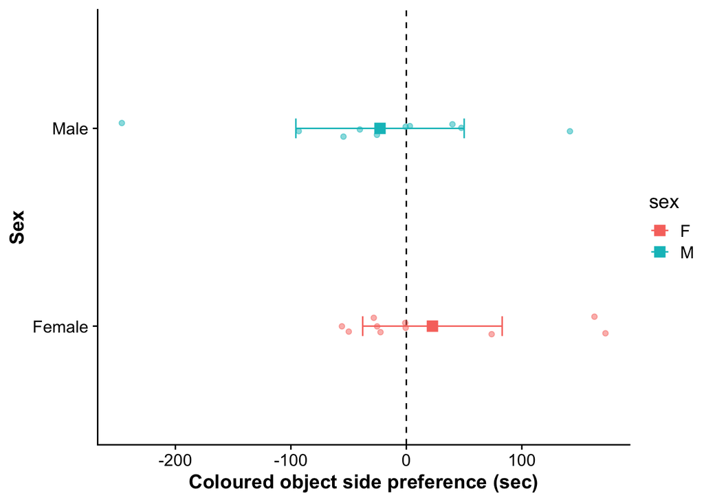

Figure 2: Preference for the side of the tank containing the coloured object separated by sex. Positive values to the right of the dashed line indicate a preference for the coloured object. Negative values to the left of the dashed line indicate a preference for the black and white object.